# Network Intrusion Detection System (IDS)

Imports

```python
import pandas as pd
import numpy as np
import tensorflow as tf
from collections.abc import Sequence
from sklearn.model_selection import train_test_split
from sklearn import preprocessing
import matplotlib.pyplot as plt
import shutil
import os
from tensorflow.keras.models import Sequential
from tensorflow.keras.layers import Dense, Dropout, Flatten
from tensorflow.keras.layers import Conv2D, MaxPooling2D
%matplotlib inline
from sklearn.metrics import roc_curve, auc
from sklearn import svm, datasets
from sklearn.metrics import confusion_matrix, classification_report
from tensorflow.keras.datasets import mnist
```

Helper functions

```python
def encode_text_dummy(df, name):
    dummies = pd.get_dummies(df[name])
    for x in dummies.columns:
        dummy_name = "{}-{}".format(name, x)
        df[dummy_name] = dummies[x]
    df.drop(name, axis=1, inplace=True)

def encode_numeric_range(df, name, normalized_low=-1, normalized_high=1,
                         data_low=None, data_high=None):
    if data_low is None:
        data_low = min(df[name])
        data_high = max(df[name])

    df[name] = ((df[name] - data_low) / (data_high - data_low)) \
               * (normalized_high - normalized_low) + normalized_low
# Convert all missing values in the specified column to the median
def missing_median(df, name):
    med = df[name].median()
    df[name] = df[name].fillna(med)

# Convert a Pandas dataframe to the x,y inputs that TensorFlow needs
def to_xy(df, target):
    result = []
    for x in df.columns:
        if x != target:
            result.append(x)
    # find out the type of the target column.
    target_type = df[target].dtypes
    target_type = target_type[0] if isinstance(target_type, Sequence) else target_type
    # Encode to int for classification, float otherwise. TensorFlow likes 32 bits.
    if target_type in (np.int64, np.int32):
        # Classification
        dummies = pd.get_dummies(df[target])
        return df[result].values.astype(np.float32), dummies.values.astype(np.float32)
    else:
        # Regression
        return df[result].values.astype(np.float32), df[target].values.astype(np.float32)

# Encode text values to indexes(i.e. [1],[2],[3] for red,green,blue).
def encode_text_index(df, name):
    le = preprocessing.LabelEncoder()
    df[name] = le.fit_transform(df[name])
    return le.classes_


# Plot a confusion matrix.
# cm is the confusion matrix, names are the names of the classes.
def plot_confusion_matrix(cm, names, title='Confusion matrix', cmap=plt.cm.Blues):
    plt.imshow(cm, interpolation='nearest', cmap=cmap)
    plt.title(title)
    plt.colorbar()
    tick_marks = np.arange(len(names))
    plt.xticks(tick_marks, names, rotation=45)
    plt.yticks(tick_marks, names)
    plt.tight_layout()
    plt.ylabel('True label')
    plt.xlabel('Predicted label')


# Plot an ROC. pred - the predictions, y - the expected output.
def plot_roc(pred,y):
    fpr, tpr, thresholds = roc_curve(y, pred)
    roc_auc = auc(fpr, tpr)

    plt.figure()
    plt.plot(fpr, tpr, label='ROC curve (area = %0.2f)' % roc_auc)
    plt.plot([0, 1], [0, 1], 'k--')
    plt.xlim([0.0, 1.0])
    plt.ylim([0.0, 1.05])
    plt.xlabel('False Positive Rate')
    plt.ylabel('True Positive Rate')
    plt.title('Receiver Operating Characteristic (ROC)')
    plt.legend(loc="lower right")
    plt.show()
```

## Load Data, Pre-Process Data, Clean Up Data

Read the data and dealth with missing values

```python
df = pd.read_csv('data.csv',header=None,na_values=['NA','?'])
```

Gave column names to the data

```python
df.columns = [ 'duration', 'protocol_type', 'service', 'flag', 'src_bytes', 'dst_bytes', 'land', 'wrong_fragment', 'urgent',
 'hot', 'num_failed_logins', 'logged_in', 'num_compromised', 'root_shell', 'su_attempted', 'num_root', 'num_file_creations',
 'num_shells', 'num_access_files', 'num_outbound_cmds', 'is_host_login', 'is_guest_login', 'count', 'srv_count', 'serror_rate',
 'srv_serror_rate', 'rerror_rate', 'srv_rerror_rate', 'same_srv_rate', 'diff_srv_rate', 'srv_diff_host_rate', 'dst_host_count',
 'dst_host_srv_count', 'dst_host_same_srv_rate', 'dst_host_diff_srv_rate', 'dst_host_same_src_port_rate', 'dst_host_srv_diff_host_rate',
 'dst_host_serror_rate', 'dst_host_srv_serror_rate', 'dst_host_rerror_rate', 'dst_host_srv_rerror_rate', 'outcome']
```

```python
df.head()
```

|  | duration | protocol_type | service | flag | src_bytes | dst_bytes | land | wrong_fragment | urgent | hot | ... | dst_host_srv_count | dst_host_same_srv_rate | dst_host_diff_srv_rate | dst_host_same_src_port_rate | dst_host_srv_diff_host_rate | dst_host_serror_rate | dst_host_srv_serror_rate | dst_host_rerror_rate | dst_host_srv_rerror_rate | outcome |
| --- | --- | --- | --- | --- | --- | --- | --- | --- | --- | --- | --- | --- | --- | --- | --- | --- | --- | --- | --- | --- | --- |
| 0 | 0 | tcp | http | SF | 181 | 5450 | 0 | 0 | 0 | 0 | ... | 9 | 1.0 | 0.0 | 0.11 | 0.0 | 0.0 | 0.0 | 0.0 | 0.0 | normal. |
| 1 | 0 | tcp | http | SF | 239 | 486 | 0 | 0 | 0 | 0 | ... | 19 | 1.0 | 0.0 | 0.05 | 0.0 | 0.0 | 0.0 | 0.0 | 0.0 | normal. |
| 2 | 0 | tcp | http | SF | 235 | 1337 | 0 | 0 | 0 | 0 | ... | 29 | 1.0 | 0.0 | 0.03 | 0.0 | 0.0 | 0.0 | 0.0 | 0.0 | normal. |
| 3 | 0 | tcp | http | SF | 219 | 1337 | 0 | 0 | 0 | 0 | ... | 39 | 1.0 | 0.0 | 0.03 | 0.0 | 0.0 | 0.0 | 0.0 | 0.0 | normal. |
| 4 | 0 | tcp | http | SF | 217 | 2032 | 0 | 0 | 0 | 0 | ... | 49 | 1.0 | 0.0 | 0.02 | 0.0 | 0.0 | 0.0 | 0.0 | 0.0 | normal. |

5 rows × 42 columns

```python
df.shape
```

```
(494021, 42)
```

Displayed all the different possible outcomes

```python
outcomes=df["outcome"].unique()
print(", ".join(outcomes)+".")
```

```
normal., buffer_overflow., loadmodule., perl., neptune., smurf., guess_passwd., pod., teardrop., portsweep., ipsweep., land., ftp_write., back., imap., satan., phf., nmap., multihop., warezmaster., warezclient., spy., rootkit..
```

Classified all the different intrusions and attacks into a group "attacks"

```python
attacks=["back.","buffer_overflow.","ftp_write.", "guess_passwd.",
       "imap.", "ipsweep.", "land.", "loadmodule.", "multihop.",
       "neptune.", "nmap.","perl.", "phf.", "pod.",
       "portsweep.", "rootkit.", "satan.", "smurf.", "spy.", "teardrop.",
       "warezclient.", "warezmaster."]
classes=["normal","attack"]
```

Loop through all the 'outcome', and if it is part of 'attacks' then mark it as attack. Otherwise, it is normal

```python
def attack_label (row):
    if row["outcome"] in attacks:
        return classes[1]
    return classes[0]
```

```python
df["result"]=df.apply(attack_label,axis=1)
```

```python
outcomes=df["result"].unique()
print(", ".join(outcomes)+".")
```

```
normal, attack.
```

Broke up all the columns into either categorical or numerical

```python
categorical=["protocol_type","service","flag"]
numerical=[ 'duration','src_bytes', 'dst_bytes', 'land', 'wrong_fragment', 'urgent',
 'hot', 'num_failed_logins', 'logged_in', 'num_compromised', 'root_shell', 'su_attempted', 'num_root', 'num_file_creations',
 'num_shells', 'num_access_files', 'num_outbound_cmds', 'is_host_login', 'is_guest_login', 'count', 'srv_count', 'serror_rate',
 'srv_serror_rate', 'rerror_rate', 'srv_rerror_rate', 'same_srv_rate', 'diff_srv_rate', 'srv_diff_host_rate', 'dst_host_count',
 'dst_host_srv_count', 'dst_host_same_srv_rate', 'dst_host_diff_srv_rate', 'dst_host_same_src_port_rate', 'dst_host_srv_diff_host_rate',
 'dst_host_serror_rate', 'dst_host_srv_serror_rate', 'dst_host_rerror_rate', 'dst_host_srv_rerror_rate']
```

Applied one hot encoding onto the categorical columns

```python
for column in df.columns :
    if column in categorical:
        encode_text_dummy(df,column)
```

```python
df.head()
```

|  | duration | src_bytes | dst_bytes | land | wrong_fragment | urgent | hot | num_failed_logins | logged_in | num_compromised | ... | flag-REJ | flag-RSTO | flag-RSTOS0 | flag-RSTR | flag-S0 | flag-S1 | flag-S2 | flag-S3 | flag-SF | flag-SH |
| --- | --- | --- | --- | --- | --- | --- | --- | --- | --- | --- | --- | --- | --- | --- | --- | --- | --- | --- | --- | --- | --- |
| 0 | 0 | 181 | 5450 | 0 | 0 | 0 | 0 | 0 | 1 | 0 | ... | 0 | 0 | 0 | 0 | 0 | 0 | 0 | 0 | 1 | 0 |
| 1 | 0 | 239 | 486 | 0 | 0 | 0 | 0 | 0 | 1 | 0 | ... | 0 | 0 | 0 | 0 | 0 | 0 | 0 | 0 | 1 | 0 |
| 2 | 0 | 235 | 1337 | 0 | 0 | 0 | 0 | 0 | 1 | 0 | ... | 0 | 0 | 0 | 0 | 0 | 0 | 0 | 0 | 1 | 0 |
| 3 | 0 | 219 | 1337 | 0 | 0 | 0 | 0 | 0 | 1 | 0 | ... | 0 | 0 | 0 | 0 | 0 | 0 | 0 | 0 | 1 | 0 |
| 4 | 0 | 217 | 2032 | 0 | 0 | 0 | 0 | 0 | 1 | 0 | ... | 0 | 0 | 0 | 0 | 0 | 0 | 0 | 0 | 1 | 0 |

5 rows × 120 columns

```python
df.drop_duplicates()
```

|  | duration | src_bytes | dst_bytes | land | wrong_fragment | urgent | hot | num_failed_logins | logged_in | num_compromised | ... | flag-REJ | flag-RSTO | flag-RSTOS0 | flag-RSTR | flag-S0 | flag-S1 | flag-S2 | flag-S3 | flag-SF | flag-SH |
| --- | --- | --- | --- | --- | --- | --- | --- | --- | --- | --- | --- | --- | --- | --- | --- | --- | --- | --- | --- | --- | --- |
| 0 | 0 | 181 | 5450 | 0 | 0 | 0 | 0 | 0 | 1 | 0 | ... | 0 | 0 | 0 | 0 | 0 | 0 | 0 | 0 | 1 | 0 |
| 1 | 0 | 239 | 486 | 0 | 0 | 0 | 0 | 0 | 1 | 0 | ... | 0 | 0 | 0 | 0 | 0 | 0 | 0 | 0 | 1 | 0 |
| 2 | 0 | 235 | 1337 | 0 | 0 | 0 | 0 | 0 | 1 | 0 | ... | 0 | 0 | 0 | 0 | 0 | 0 | 0 | 0 | 1 | 0 |
| 3 | 0 | 219 | 1337 | 0 | 0 | 0 | 0 | 0 | 1 | 0 | ... | 0 | 0 | 0 | 0 | 0 | 0 | 0 | 0 | 1 | 0 |
| 4 | 0 | 217 | 2032 | 0 | 0 | 0 | 0 | 0 | 1 | 0 | ... | 0 | 0 | 0 | 0 | 0 | 0 | 0 | 0 | 1 | 0 |
| ... | ... | ... | ... | ... | ... | ... | ... | ... | ... | ... | ... | ... | ... | ... | ... | ... | ... | ... | ... | ... | ... |
| 494016 | 0 | 310 | 1881 | 0 | 0 | 0 | 0 | 0 | 1 | 0 | ... | 0 | 0 | 0 | 0 | 0 | 0 | 0 | 0 | 1 | 0 |
| 494017 | 0 | 282 | 2286 | 0 | 0 | 0 | 0 | 0 | 1 | 0 | ... | 0 | 0 | 0 | 0 | 0 | 0 | 0 | 0 | 1 | 0 |
| 494018 | 0 | 203 | 1200 | 0 | 0 | 0 | 0 | 0 | 1 | 0 | ... | 0 | 0 | 0 | 0 | 0 | 0 | 0 | 0 | 1 | 0 |
| 494019 | 0 | 291 | 1200 | 0 | 0 | 0 | 0 | 0 | 1 | 0 | ... | 0 | 0 | 0 | 0 | 0 | 0 | 0 | 0 | 1 | 0 |
| 494020 | 0 | 219 | 1234 | 0 | 0 | 0 | 0 | 0 | 1 | 0 | ... | 0 | 0 | 0 | 0 | 0 | 0 | 0 | 0 | 1 | 0 |

145586 rows × 120 columns

Normalized the numerical columns and filled in the missing values with the median

```python
for column in df.columns:
    if column in numerical:
        encode_numeric_range(df,column)
        missing_median(df,column)
```

```python
df.shape
```

```
(494021, 120)
```

Dropped uncessary columns and prepped the data for our model

```python
df.drop('outcome',axis=1,inplace=True)
df.drop('num_outbound_cmds',axis=1,inplace=True)
df.drop('is_host_login',axis=1,inplace=True)
result=encode_text_index(df,'result')
x,y=to_xy(df,'result')
```

```python
x.shape
```

```
(494021, 116)
```

Split the data into 20% test and 80% train

```python
x_train, x_test, y_train, y_test = train_test_split(x, y, test_size=0.2, random_state=42)
```

```python
print(x_train.shape)
print(y_train.shape)
print(x_test.shape)
print(y_test.shape)
x_train
```

```
(395216, 116)
(395216, 2)
(98805, 116)
(98805, 2)
```

```
array([[-1.       , -0.999997 , -1.       , ...,  0.       ,  1.       ,
         0.       ],
       [-1.       , -1.       , -1.       , ...,  0.       ,  0.       ,
         0.       ],
       [-1.       , -1.       , -1.       , ...,  0.       ,  0.       ,
         0.       ],
       ...,
       [-1.       , -0.999997 , -1.       , ...,  0.       ,  1.       ,
         0.       ],
       [-0.686571 , -0.9999996, -0.9999593, ...,  0.       ,  1.       ,
         0.       ],
       [-1.       , -1.       , -1.       , ...,  0.       ,  0.       ,
         0.       ]], dtype=float32)
```

## Train the Model

Tuning the different parameters and taking note of the different results. Different parameters include Activision: relu, sigmoid, tanh. Number of layers and neurons. Optimizer:adam, sgd. Kernel number and kernel size (CNN only)

### Fully-Connected Neural Networks

```python
from tensorflow.keras.models import Sequential
from tensorflow.keras.layers import Dense, Activation, Dropout
from tensorflow.keras.callbacks import EarlyStopping
from tensorflow.keras import optimizers
from tensorflow.keras.callbacks import ModelCheckpoint
from sklearn import metrics


checkpointer = ModelCheckpoint(filepath="dnn/best_weights.hdf5", verbose=0, save_best_only=True) # save best model
for i in range(2):
    print(i)

    model = Sequential()
    model.add(Dense(10, input_dim=x.shape[1], activation='tanh'))
    model.add(Dense(32))
    model.add(Dense(64))
    model.add(Dense(128))
    model.add(Dense(256))
    model.add(Dense(y.shape[1], activation='tanh'))

    adam = optimizers.Adam(lr=0.0001, beta_1=0.9, beta_2=0.999, epsilon=None, decay=0.0, amsgrad=False)
    model.compile(loss='mean_squared_error', optimizer=adam)

    monitor = EarlyStopping(monitor='val_loss', min_delta=1e-3, patience=5, verbose=1, mode='auto')


    # batch_size: Integer or None. Number of samples per gradient update. If unspecified, batch_size will default to 32.
    model.fit(x_train,y_train,validation_data=(x_test,y_test), batch_size= 128, callbacks=[monitor,checkpointer],verbose=2,epochs=1000)



model.load_weights('dnn/best_weights.hdf5')

# Predict and measure RMSE
pred = model.predict(x_test)

score = np.sqrt(metrics.mean_squared_error(pred,y_test))
print("Score (RMSE): {}".format(score))
```

```
0
WARNING:tensorflow:From C:\Users\omgit\anaconda3\lib\site-packages\tensorflow\python\ops\init_ops.py:1251: calling VarianceScaling.__init__ (from tensorflow.python.ops.init_ops) with dtype is deprecated and will be removed in a future version.
Instructions for updating:
Call initializer instance with the dtype argument instead of passing it to the constructor
Train on 395216 samples, validate on 98805 samples
395216/395216 - 4s - loss: 0.0236 - val_loss: 0.0105
395216/395216 - 4s - loss: 0.0093 - val_loss: 0.0086
395216/395216 - 4s - loss: 0.0076 - val_loss: 0.0073
395216/395216 - 4s - loss: 0.0068 - val_loss: 0.0067
395216/395216 - 4s - loss: 0.0064 - val_loss: 0.0064
395216/395216 - 4s - loss: 0.0061 - val_loss: 0.0062
395216/395216 - 4s - loss: 0.0059 - val_loss: 0.0060
395216/395216 - 4s - loss: 0.0057 - val_loss: 0.0057
395216/395216 - 4s - loss: 0.0054 - val_loss: 0.0055
395216/395216 - 4s - loss: 0.0052 - val_loss: 0.0052
395216/395216 - 4s - loss: 0.0050 - val_loss: 0.0050
395216/395216 - 4s - loss: 0.0048 - val_loss: 0.0048
395216/395216 - 4s - loss: 0.0046 - val_loss: 0.0046
395216/395216 - 4s - loss: 0.0045 - val_loss: 0.0045
395216/395216 - 4s - loss: 0.0043 - val_loss: 0.0043
395216/395216 - 4s - loss: 0.0042 - val_loss: 0.0041
Epoch 00016: early stopping
1
Train on 395216 samples, validate on 98805 samples
395216/395216 - 4s - loss: 0.0207 - val_loss: 0.0092
395216/395216 - 4s - loss: 0.0080 - val_loss: 0.0075
395216/395216 - 4s - loss: 0.0070 - val_loss: 0.0069
395216/395216 - 4s - loss: 0.0065 - val_loss: 0.0063
395216/395216 - 4s - loss: 0.0061 - val_loss: 0.0060
395216/395216 - 4s - loss: 0.0058 - val_loss: 0.0058
395216/395216 - 4s - loss: 0.0055 - val_loss: 0.0054
395216/395216 - 4s - loss: 0.0053 - val_loss: 0.0052
395216/395216 - 4s - loss: 0.0051 - val_loss: 0.0051
395216/395216 - 4s - loss: 0.0049 - val_loss: 0.0048
395216/395216 - 5s - loss: 0.0047 - val_loss: 0.0047
395216/395216 - 6s - loss: 0.0045 - val_loss: 0.0046
395216/395216 - 4s - loss: 0.0044 - val_loss: 0.0044
Epoch 00013: early stopping
Score (RMSE): 0.06438760459423065
```

## Data Results/Analysis

Using the trained model, showed different findings. We first Plotted the confusion matrix and displayed the precision, recall and f1-score of our model. Lastly we showed the RMSE score of our model.

```
[[79039   413]
 [   61 19292]]
Ploting confusion matrix
```

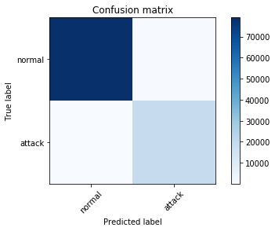

```
              precision    recall  f1-score   support

           0       1.00      0.99      1.00     79452
           1       0.98      1.00      0.99     19353

    accuracy                           1.00     98805
   macro avg       0.99      1.00      0.99     98805
weighted avg       1.00      1.00      1.00     98805

Score (RMSE): 0.06438760459423065
```

```python
pred2 = model.predict(x_test)
pred2 = np.argmax(pred,axis=1)
y_true = np.argmax(y_test,axis=1)

# Compute confusion matrix
cm = confusion_matrix(y_true, pred2)
print(cm)

print('Ploting confusion matrix')
plt.figure()
plot_confusion_matrix(cm, ('normal','attack'))
plt.show()


print(classification_report(y_true, pred2))
print("Score (RMSE): {}".format(score))
```

```python
from tensorflow.keras.datasets import mnist
from tensorflow.keras.models import Sequential
from tensorflow.keras.layers import Dense, Dropout, Flatten
from tensorflow.keras.layers import Conv2D, MaxPooling2D
from collections.abc import Sequence
from sklearn import preprocessing
import matplotlib.pyplot as plt
import numpy as np
import pandas as pd
import shutil
import os
```

```python
x
```

```
array([[-1.        , -0.99999946, -0.99788576, ...,  0.        ,
         1.        ,  0.        ],
       [-1.        , -0.9999993 , -0.9998115 , ...,  0.        ,
         1.        ,  0.        ],
       [-1.        , -0.99999934, -0.9994813 , ...,  0.        ,
         1.        ,  0.        ],
       ...,
       [-1.        , -0.9999994 , -0.9995345 , ...,  0.        ,
         1.        ,  0.        ],
       [-1.        , -0.99999917, -0.9995345 , ...,  0.        ,
         1.        ,  0.        ],
       [-1.        , -0.99999934, -0.99952126, ...,  0.        ,
         1.        ,  0.        ]], dtype=float32)
```

```python
xxx=x[:10000]
yyy=y[:10000]
```

```python
xxx.shape
```

```
(10000, 116)
```

```python
xx = xxx.reshape((10000, 1, 128, 1))
yy=tf.keras.utils.to_categorical(yyy, 3)
```

[output not shown]

```python
xx
```

```
array([[[[-1.        ],
         [-0.99999946],
         [-0.99788576],
         ...,
         [ 0.        ],
         [ 1.        ],
         [ 0.        ]]],


       [[[-1.        ],
         [-0.9999993 ],
         [-0.9998115 ],
         ...,
         [ 0.        ],
         [ 1.        ],
         [ 0.        ]]],


       [[[-1.        ],
         [-0.99999934],
         [-0.9994813 ],
         ...,
         [ 0.        ],
         [ 1.        ],
         [ 0.        ]]],


       ...,


       [[[-1.        ],
         [-0.999997  ],
         [-1.        ],
         ...,
         [ 0.        ],
         [ 1.        ],
         [ 0.        ]]],


       [[[-1.        ],
         [-0.999997  ],
         [-1.        ],
         ...,
         [ 0.        ],
         [ 1.        ],
         [ 0.        ]]],


       [[[-1.        ],
         [-0.999997  ],
         [-1.        ],
         ...,
         [ 0.        ],
         [ 1.        ],
         [ 0.        ]]]], dtype=float32)
```

```python
# Load modules
import tensorflow as tf
from tensorflow.keras.datasets import mnist
from tensorflow.keras.models import Sequential
from tensorflow.keras.layers import Dense, Dropout, Flatten
from tensorflow.keras.layers import Conv2D, MaxPooling2D
```

```python
# define a CNN

cnn = Sequential()
cnn.add(Conv2D(256, kernel_size=(1, 3), strides=(1, 1),
                 activation='tanh',
                 input_shape=(1, 128, 1)))

# the above code is equivalent to
# model.add(Conv1D(64, kernel_size=3, strides=1, activation='relu', input_shape=(128, 1)))

cnn.add(MaxPooling2D(pool_size=(1,2)))

cnn.add(Conv2D(256, kernel_size=(1, 3), strides=(1, 1),
                 activation='tanh'))
cnn.add(MaxPooling2D(pool_size=(1,2)))


cnn.add(Flatten())
cnn.add(Dense(1024, activation="tanh"))
cnn.add(Dropout(0.5))
cnn.add(Dense(3, activation="softmax"))

# define optimizer and objective, compile cnn

cnn.compile(loss="categorical_crossentropy", optimizer="adam")
```

```python
x_train, x_test, y_train, y_test = train_test_split(xx, yy, test_size=0.2, random_state=42)
```

```python
# Nicely formatted time string
def hms_string(sec_elapsed):
    h = int(sec_elapsed / (60 * 60))
    m = int((sec_elapsed % (60 * 60)) / 60)
    s = sec_elapsed % 60
    return "{}:{:>02}:{:>05.2f}".format(h, m, s)
```

```python
import time

start_time = time.time()
checkpointer = ModelCheckpoint(filepath="dnn/best_weights.hdf5", verbose=0, save_best_only=True) # save best model
for i in range(2):
    print(i)


    cnn.fit(x_train[0:9000], y_train[0:9000],
              batch_size=64,
              epochs=10,
              verbose=2,
               callbacks=[monitor,checkpointer],
              validation_data=(x_test[0:300], y_test[0:300]))

pred2=cnn.predict(x_test)

score2 = np.sqrt(metrics.mean_squared_error(pred2,y_test))
print("Score (RMSE): {}".format(score2))

elapsed_time = time.time() - start_time
print("Elapsed time: {}".format(hms_string(elapsed_time)))
```

```
0
```

[output not shown]

```python
cnn.summary()
```

```
Model: "sequential_6"
_________________________________________________________________
Layer (type)                 Output Shape              Param #
=================================================================
conv2d_8 (Conv2D)            (None, 1, 126, 256)       1024
_________________________________________________________________
max_pooling2d_8 (MaxPooling2 (None, 1, 63, 256)        0
_________________________________________________________________
conv2d_9 (Conv2D)            (None, 1, 61, 256)        196864
_________________________________________________________________
max_pooling2d_9 (MaxPooling2 (None, 1, 30, 256)        0
_________________________________________________________________
flatten_4 (Flatten)          (None, 7680)              0
_________________________________________________________________
dense_18 (Dense)             (None, 1024)              7865344
_________________________________________________________________
dropout_4 (Dropout)          (None, 1024)              0
_________________________________________________________________
dense_19 (Dense)             (None, 3)                 3075
=================================================================
Total params: 8,066,307
Trainable params: 8,066,307
Non-trainable params: 0
_________________________________________________________________
```